# Analyse des scénarios Idefese

8/28/2020

## Introduction

## Messages globaux

- les variations que l’on a simulées sont quasi-systématiquement **négligeables**
  - il faudrait bien revérifier les paramètres dans Invest ?
- l’action sur les parcs (plantation d’arbres dans les rues etc.) ont un impact qui peut être très grand devant les choix d’aménagement de la région (SDRIF etc.)
  - nous n’avons pas modélisé de changement de pratique agricole -> cela pourrait être intéressant

## Scénarios 1/3

(Pour l’instant) 4 grands types de scénarios:

- INSEE : basés sur les scénarios démographiques de l’INSEE + un modèle géographique
- SDRIF : on suppose que les objectifs du SDRIF sont remplis avec différents types d’urbanisation
- Changement des parcs : on végétalise la ville actuelle
- Densification: on remplace les parcs par des logements

Le lien entre type d’habitat et densité de population vient de ce [document de l’IAU](https://www.institutparisregion.fr/fileadmin/NewEtudes/Etude_762/Densites_Referentiel.pdf) https://www.institutparisregion.fr/fileadmin/NewEtudes/Etude_762/Densites_Referentiel.pdf

## Scénarios 2/3

Aperçu des scénarios (tout est dans le doc `Description Scenarios et Services.xlsx` )

| scenario_type | Nom | Description |
| --- | --- | --- |
| Densification | Scénario de Densification Lotissement | Parcs et jardins des zones morphologiques 1&2 (du découpage morphologique d’IDF) deviennent des lotissements |
| Densification | Scénario de Densification Habitat Rural | Parcs et jardins des zones morphologiques 1&2 (du découpage morphologique d’IDF) deviennent des habitats ruraux |
| Densification | Scénario de Densification Habitat Collectif | Parcs et jardins des zones morphologiques 1&2 (du découpage morphologique d’IDF) deviennent des habitats collectifs |
| Changement des parcs | Végétalisation: Parcs et Jardins | Transfomer les Espaces ouverts à végétation arbustive ou herbacée, les urfaces engazonnées avec ou sans arbustes et Terrains Vacants en parcs et jardins |
| Changement des parcs | Végétalisation: Forêts | Transfomer les Espaces ouverts à végétation arbustive ou herbacée, les urfaces engazonnées avec ou sans arbustes et Terrains Vacants en bois et forets |
| Changement des parcs | Parcs et jardins ==> Foret | Parcs et jardins d’IDF deviennent de la foret |
| INSEE | INSEE haut - habitat rural isolé | Projections de population INSEE – scénario haut - avec tous les nouveaux arrivants logés dans des habitats ruraux en construction isolée. Expansion urbaine avec Sleuth |
| INSEE | INSEE haut - habitat collectif continu haut | Projections de population INSEE – scénario haut - avec tous les nouveaux arrivants logés dans de l’habitat collectif haut. Expansion urbaine avec Sleuth |
| INSEE | INSEE haut - lotissements | Projections de population INSEE – scénario haut- avec tous les nouveaux arrivants logés dans des lostissements (poste 30 du mos81p). Expansion urbaine avec Sleuth |
| INSEE | INSEE central - lotissements | Projections de population INSEE – scénario central - avec tous les nouveaux arrivants logés dans des lostissements (poste 30 du mos81p). Expansion urbaine avec Sleuth |
| SDRIF | SDRIF Lotissements | Urbanisation des zones du SDRIF marquées comme “Secteurs d’urbanisation préférentielle” et “Secteurs d’urbanisation conditionnelle” avec des construction de type Lotissements |
| SDRIF | SDRIF Habitat Rural | Urbanisation des zones du SDRIF marquées comme “Secteurs d’urbanisation préférentielle” et “Secteurs d’urbanisation conditionnelle” avec des construction de type Habitat Rural |
| SDRIF | SDRIF Habitat Collectif | Urbanisation des zones du SDRIF marquées comme “Secteurs d’urbanisation préférentielle” et “Secteurs d’urbanisation conditionnelle” avec des construction de type Habitat Collectif |
| INSEE | SLUM INSEE haut - habitat rural isolé | Projections de population INSEE – scénario haut - avec tous les nouveaux arrivants logés dans des habitats ruraux en construction isolée. Expansion urbaine avec SLUM |
| INSEE | SLUM INSEE haut - habitat collectif continu haut | Projections de population INSEE – scénario haut - avec tous les nouveaux arrivants logés dans de l’habitat collectif haut. Expansion urbaine avec SLUM |
| INSEE | SLUM INSEE haut - lotissements | Projections de population INSEE – scénario haut- avec tous les nouveaux arrivants logés dans des lostissements (poste 30 du mos81p). Expansion urbaine avec SLUM |
| INSEE | SLUM INSEE central - lotissements | Projections de population INSEE – scénario central - avec tous les nouveaux arrivants logés dans des lostissements (poste 30 du mos81p). Expansion urbaine avec SLUM |
| Changement des parcs | Pietonnisation Jardins | On transformes les emprises de transport ferré et les voies de plus de 25 m d’emprise dans toute la région en jardins publics |
| INSEE | SLUM INSEE haut - habitat rural isolé - mini | Projections de population INSEE – scénario haut - avec tous les nouveaux arrivants logés dans des habitats ruraux en construction isolée. Expansion urbaine avec SLUM + Exclusion des zones dans le Gran… |
| INSEE | SLUM INSEE haut - habitat collectif continu haut - mini | Projections de population INSEE – scénario haut - avec tous les nouveaux arrivants logés dans de l’habitat collectif haut. Expansion urbaine avec SLUM + Exclusion des zones dans le Grand Paris contrib… |
| INSEE | SLUM INSEE haut - lotissements - mini | Projections de population INSEE – scénario haut- avec tous les nouveaux arrivants logés dans des lostissements (poste 30 du mos81p). Expansion urbaine avec SLUM + Exclusion des zones dans le Grand Par… |
| INSEE | SLUM INSEE central - lotissements - mini | Projections de population INSEE – scénario central - avec tous les nouveaux arrivants logés dans des lostissements (poste 30 du mos81p). Expansion urbaine avec SLUM + Exclusion des zones dans le Grand… |

## Scénarios 3/3

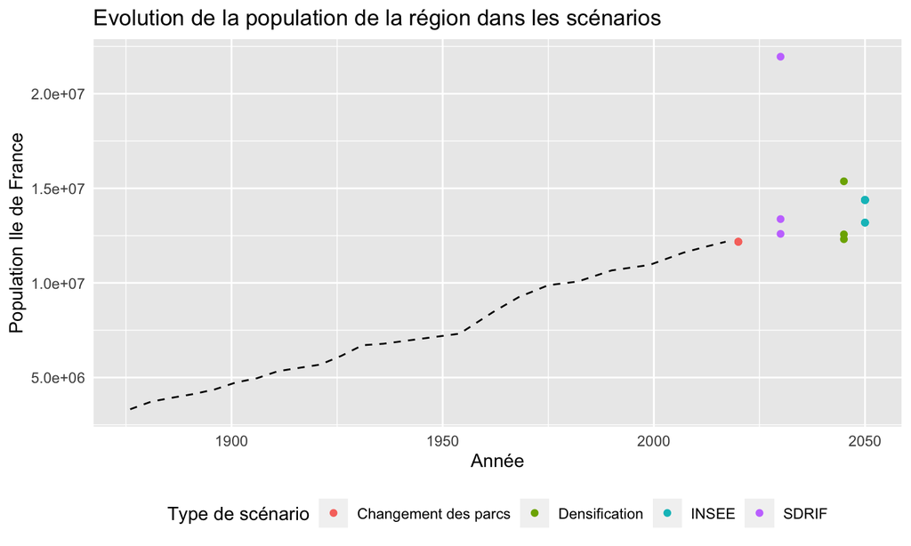

## Résultats des simulations

Tout est en ligne aux adresses:

https://public.tableau.com/profile/mikou#!/vizhome/Variation_SE/Variation_1?publish=yes

https://public.tableau.com/profile/mikou#!/vizhome/Variation_SE/Evolution_1?publish=yes

## Vue globale des services

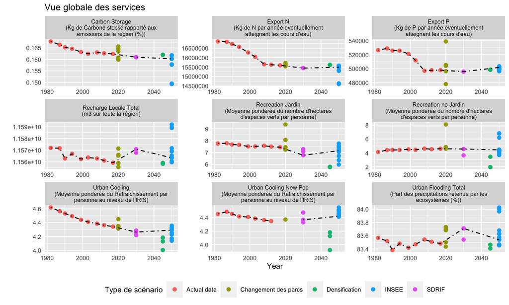

## Analyse des services

## Carbon capture (1/2)

- **Scénarios INSEE et SDRIF** : décroissance dans la lignée des évolutions historiques
- **Scénarios de changement des parcs** : on arrive à remonter un peu
- **au total** : les changements sont toujours négligeables

## Carbon capture (2/2)

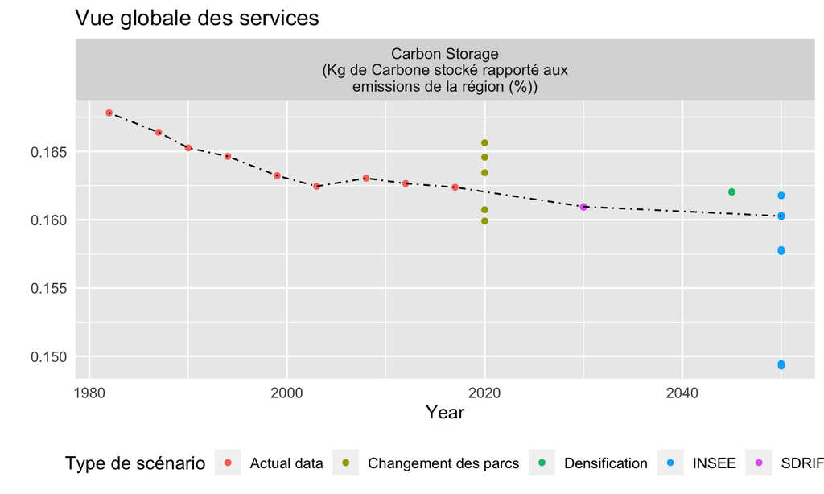

## Exports de N et P (1/2)

- export N : peu d’impacts de nos scénarios (à part 2 scénarios INSEE extrêmes)
- export P : le message est un peu différent : gros impacts des scénarios de modification des parcs actuels
  - vérifier le paramétrage ?
- zéro différence entre les scénarios SDRIF…
- dans tous les cas, variation négligeable ?

## Exports de N et P (2/2)

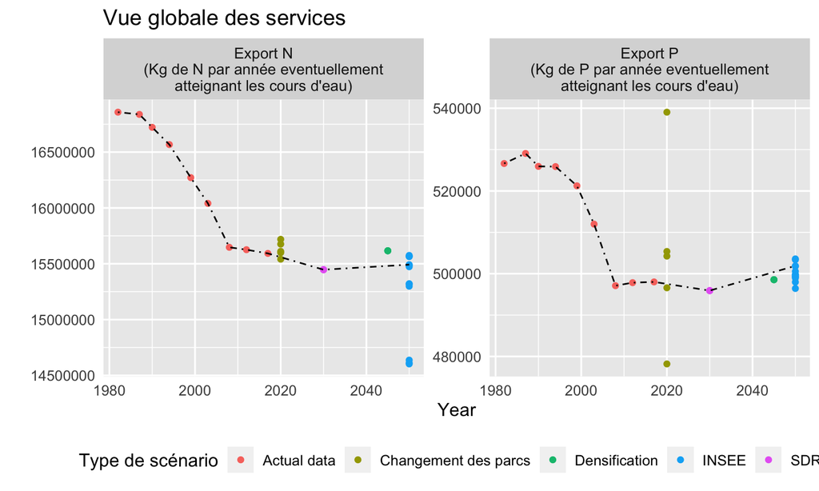

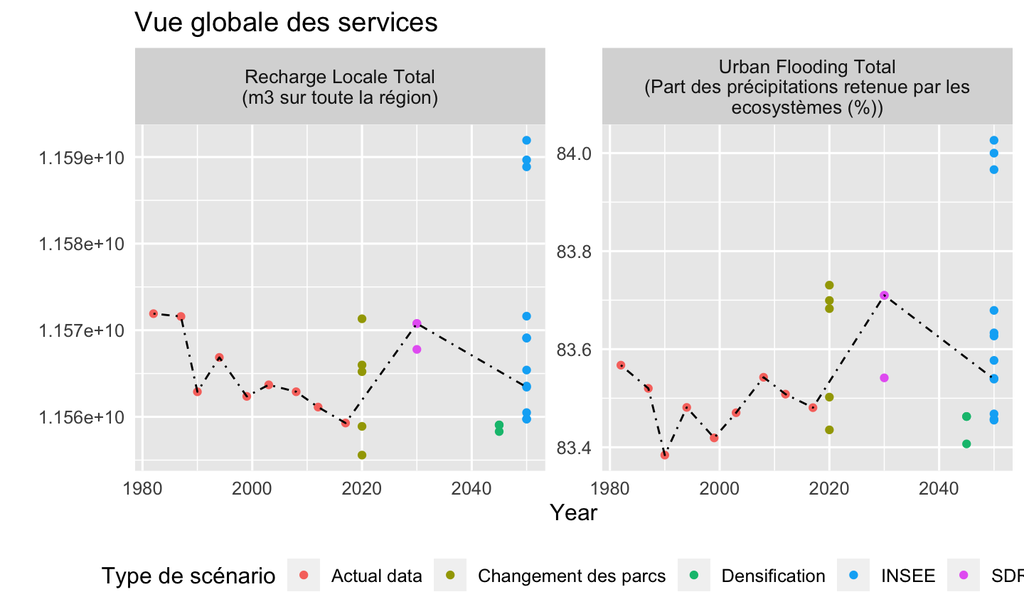

## cartes par bassins versants 1

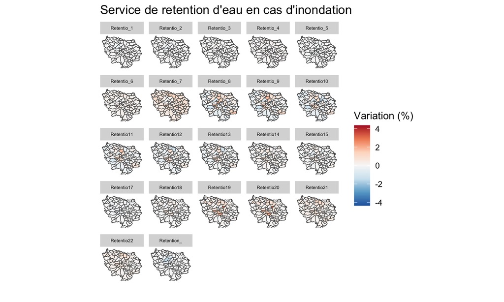

## cartes par bassins versants 2

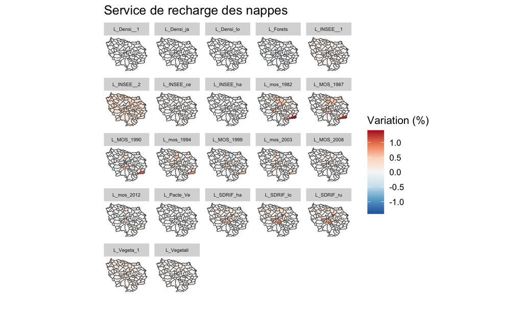

## Urban Cooling (1/2)

- Variation très faible (< 0.5°C)
- une question intéressante: l’évolution n’est pas la même pour les nouveaux habitants, et pour ceux déjà en place

## Urban Cooling (2/2)

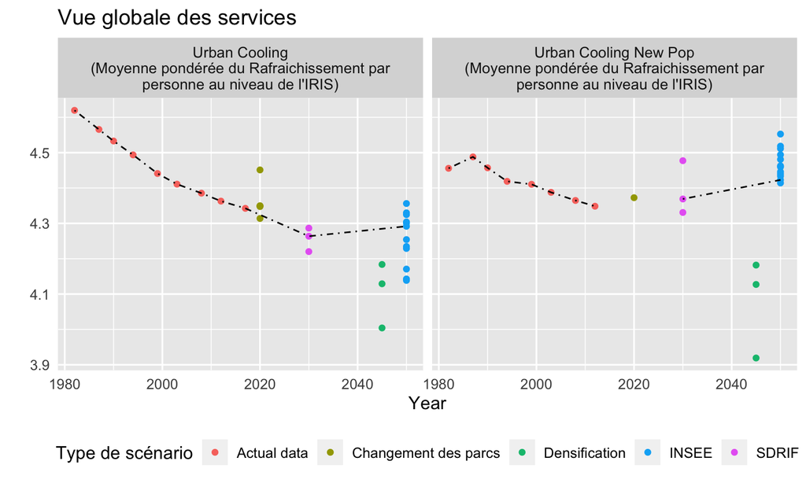

## Recreation (1/2)

- le modèle le plus sensible
- Mais aussi celui sur lequel il y a le moins de littérature…
- les résultats dépendent fortement de si on inclut dans la récréation les jardins privés ou non
  - On a fait 2 catégories: la récréation pour ceux qui ont un jardin, et pour ceux qui n’en ont pas

## Recreation (2/2)

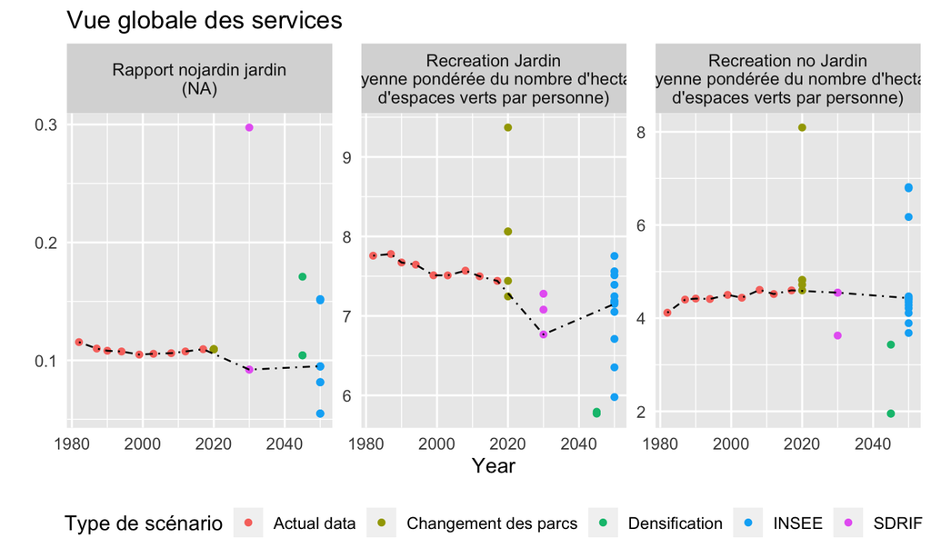